# Re-analysis of PNG cohort using the Pf3k pipeline

Stuart Lee

2016-07-12

# Contents

```r
# packages
pkgs <- c("moimix", "SeqArray", "dplyr",
          "readr", "ggplot2", "knitr", "tidyr", "grid")
inst <- lapply(pkgs, library, character.only = TRUE)
# ggplot options
theme_set(theme_bw())
# knitr options
opts_chunk$set(warning = FALSE, echo = FALSE, message = FALSE,
             fig.path = "./report_figures/",
             cache.path = "./report_cache/")
qc_path <- "data/qc/"

# added by bpipe after running post-alignment steps of pipeline
bpipe_prefix <- ".reverted.markilluminaadapters.remapBWA.realignindels.dedup.bqsrApply."
final_vcf <- "cache/final_snps.cleanGDS.gds"

# check OS system
os <- Sys.info()['sysname']

if (os == 'Darwin') {
  # binaries for manipulating VCF files
  vcftools_bin <- "/Users/lee.s/anaconda/bin/vcftools"
  vcf2npy_bin <- "/Users/lee.s/anaconda/envs/py2/bin/vcf2npy"
  vcfnpy2hdf5_bin <-"/Users/lee.s/anaconda/envs/py2/bin/vcfnpy2hdf5"
  bgzip <- "/Users/lee.s/anaconda/envs/py2/bin/bgzip"
  tabix <- "/Users/lee.s/anaconda/envs/py2/bin/tabix -p vcf"


} else {
  # binaries for manipulating VCF files
  vcftools_bin <- "/usr/local/bioinf/bin/vcftools"
  vcf2npy_bin <- "~/.local/bin/vcf2npy"
  vcfnpy2hdf5_bin <-"~/.local/bin/vcfnpy2hdf5"
  bgzip <- "/usr/local/bioinf/bin/bgzip"
  tabix <- "/usr/local/bioinf/bin/tabix -p vcf"
}
```

# 1 Introduction

Here we describe realignment and variant calling of 152 *P.falciparum* isolates from Papua New Guinea.

The new pipeline we created is our attempt at replicating the Malaria Genomics Pf3k projects analysis pipeline. It is our hope that we can integrate this updated data into a global analysis of selection and relatedness.

For the pipeline documentation and details please see: https://github.com/bahlolab/pf_variant_calling_pipeline

# 2 Variant and Sample Quality Assessment

Although the pipeline we have written should in principle output a clean VCF/GDS file as its final output - we just make sure that the preliminary steps of the pipeline have produced reasonable output. We also filter samples and/or variants that are poor quality based on one or more of the following characteristics:

- high missingess
- poor alignment/mapping to the 3D7 reference genome
- poor coverage
- errors caused by sequencing artefacts (i.e. strand bias)

## 2.1 Alignment summary statistics

We ran Picardtools CollectAlignmentSummary metrics and CollectInsertSizeMetrics to find estimates of total read counts, total reads aligned to the reference, average fragment lengths. These were all estimated post alignment with BWA-MEM and recalibrating base qualities scores with GATK.

We summarise the alignment outputs for all samples in the table below, sorted by proportion of reads passing filtering that align to the reference genome.

| sample_id | read_length | total_reads | total_reads_aligned | percent_reads_aligned | total_high_qual_reads_aligned | total_q20_bases_aligned | total_reads_aligned_in_pairs | percent_reads_aligned_in_pairs | bad_cycles | percent_chimeras | percent_adapter | percent_high_qual_aligned |
| --- | --- | --- | --- | --- | --- | --- | --- | --- | --- | --- | --- | --- |
| PN0173_C | 100.0 | 31329551 | 30915995 | 1.0 | 28704033 | 2742912244 | 30878898 | 1.0 | 0 | 0.0 | 0.0 | 0.9 |
| PN0179_C | 100.0 | 32425950 | 31994241 | 1.0 | 29655980 | 2835316851 | 31956252 | 1.0 | 0 | 0.0 | 0.0 | 0.9 |
| PN0166_C | 100.0 | 33085731 | 32631659 | 1.0 | 30529268 | 2927497476 | 32595406 | 1.0 | 0 | 0.0 | 0.0 | 0.9 |
| PN0177_C | 100.0 | 31070369 | 30628943 | 1.0 | 28310648 | 2705125786 | 30588714 | 1.0 | 0 | 0.0 | 0.0 | 0.9 |
| PN0192_C | 100.0 | 27310617 | 26848250 | 1.0 | 24728131 | 2361041984 | 26808490 | 1.0 | 0 | 0.0 | 0.0 | 0.9 |
| PN0086_C | 100.0 | 14746147 | 14496354 | 1.0 | 13423421 | 1273057265 | 14454574 | 1.0 | 0 | 0.0 | 0.0 | 0.9 |
| PN0121_C | 100.0 | 31235578 | 30702157 | 1.0 | 28561148 | 2706659189 | 30660970 | 1.0 | 0 | 0.0 | 0.0 | 0.9 |
| PN0182_C | 100.0 | 35652445 | 35039239 | 1.0 | 32358815 | 3094436000 | 34997934 | 1.0 | 0 | 0.0 | 0.0 | 0.9 |
| PN0178_C | 100.0 | 33080904 | 32503664 | 1.0 | 30012343 | 2863429505 | 32461402 | 1.0 | 0 | 0.0 | 0.0 | 0.9 |
| PN0154_C | 100.0 | 31573672 | 31013607 | 1.0 | 28930445 | 2771458602 | 30971394 | 1.0 | 0 | 0.0 | 0.0 | 0.9 |
| PN0159_C | 100.0 | 30210081 | 29668752 | 1.0 | 27325536 | 2608309911 | 29628708 | 1.0 | 0 | 0.0 | 0.0 | 0.9 |
| PN0077_C | 100.0 | 13472682 | 13225833 | 1.0 | 12284962 | 1166896946 | 13183342 | 1.0 | 0 | 0.0 | 0.0 | 0.9 |
| PN0176_C | 100.0 | 30914140 | 30330714 | 1.0 | 27910297 | 2664958511 | 30288352 | 1.0 | 0 | 0.0 | 0.0 | 0.9 |
| PN0186_C | 100.0 | 31527840 | 30916367 | 1.0 | 28720117 | 2745136141 | 30875798 | 1.0 | 0 | 0.0 | 0.0 | 0.9 |
| PN0169_C | 100.0 | 27878467 | 27328848 | 1.0 | 25352664 | 2425178509 | 27289138 | 1.0 | 0 | 0.0 | 0.0 | 0.9 |
| PNG_XUC022 | 101.0 | 28239533 | 27681015 | 1.0 | 26035036 | 2375455310 | 27605036 | 1.0 | 0 | 0.0 | 0.0 | 0.9 |
| PN0191_C | 100.0 | 27948736 | 27393489 | 1.0 | 25512443 | 2437821312 | 27352280 | 1.0 | 0 | 0.0 | 0.0 | 0.9 |
| PN0073_C | 100.0 | 20853745 | 20437907 | 1.0 | 18833481 | 1789285877 | 20385308 | 1.0 | 0 | 0.0 | 0.0 | 0.9 |
| PN0151_C | 100.0 | 26812886 | 26266660 | 1.0 | 24392233 | 2314071752 | 26225010 | 1.0 | 0 | 0.0 | 0.0 | 0.9 |
| PN0113_C | 100.0 | 30191462 | 29553296 | 1.0 | 27569097 | 2608597823 | 29508418 | 1.0 | 0 | 0.0 | 0.0 | 0.9 |
| PN0180_C | 100.0 | 26767268 | 26194296 | 1.0 | 24227094 | 2311297831 | 26154836 | 1.0 | 0 | 0.0 | 0.0 | 0.9 |
| PN0109_C | 100.0 | 19300436 | 18881900 | 1.0 | 17553435 | 1663305473 | 18843728 | 1.0 | 0 | 0.0 | 0.0 | 0.9 |
| PN0008_C | 100.0 | 17110168 | 16736385 | 1.0 | 15557837 | 1478045747 | 16657148 | 1.0 | 0 | 0.0 | 0.0 | 0.9 |
| PNG_XUC009 | 101.0 | 28999834 | 28357388 | 1.0 | 26215261 | 2368659855 | 28281138 | 1.0 | 0 | 0.0 | 0.0 | 0.9 |
| PN0124_C | 100.0 | 26572357 | 25978233 | 1.0 | 24073189 | 2273441157 | 25931102 | 1.0 | 0 | 0.0 | 0.0 | 0.9 |
| PN0141_C | 100.0 | 29965804 | 29295283 | 1.0 | 26977833 | 2551760514 | 29252774 | 1.0 | 0 | 0.0 | 0.0 | 0.9 |
| PN0118_C | 100.0 | 29819888 | 29145496 | 1.0 | 27044204 | 2562803983 | 29096280 | 1.0 | 0 | 0.0 | 0.0 | 0.9 |
| PN0078_C | 100.0 | 15067173 | 14719154 | 1.0 | 13652882 | 1295319900 | 14598546 | 1.0 | 0 | 0.0 | 0.0 | 0.9 |
| PNG_XIA508 | 101.0 | 27690610 | 27034447 | 1.0 | 25198722 | 2292482450 | 26943274 | 1.0 | 0 | 0.0 | 0.0 | 0.9 |
| PN0165_C | 100.0 | 32536709 | 31758974 | 1.0 | 29229114 | 2785481028 | 31712028 | 1.0 | 0 | 0.0 | 0.0 | 0.9 |

[output cut: 122 more lines]

We see that several isolates have not aligned at all to the 3D7 reference genome, or are poorly aligned to reference genome. These isolates have been found in our other pipeline to align completely to the Pvivax genome or have very low quantities of parasite DNA or have high amounts of adapter contamination.

We also look at the insert size distributions and save the output for checking clonality in estMOI. Everything looks fine here - not much difference between means and median insert size distributions.

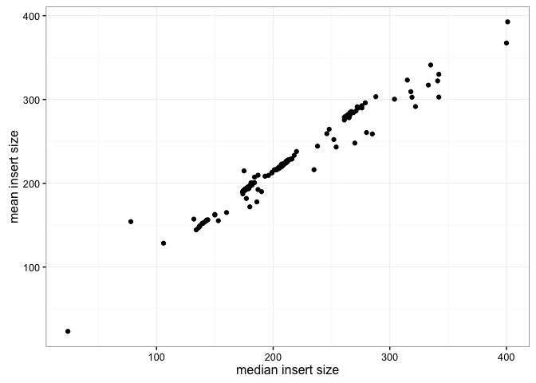

## 2.2 Depth of coverage

We estimated coverage using GATK’s Depth of Coverage both within sample and over genomic intervals that overlap known drug resistance genes and surface antigen genes. For both coverage estimates we restricted counting to only include bases where the base-quality score was greater than 20 and only include reads where the mapping-quality score was greater than 20.

First we plot the distributions of mean coverage, median coverage, and the proportion of bases covered up to 1, 5, and 10 reads respectively.

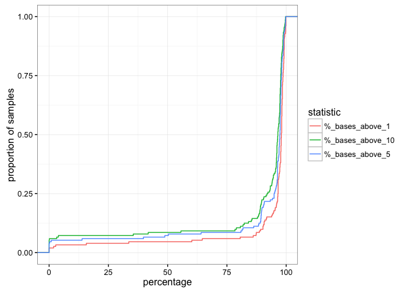

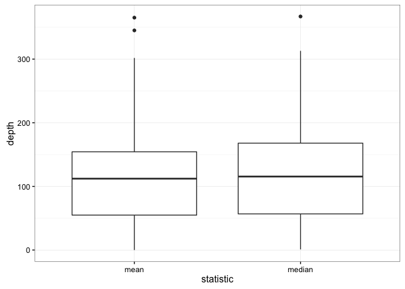

Boxplots of coverage statistics

From both of these boxplots we see that most samples are generally well covered, with the average and median coverages of the data at about 100x. Futhermore, about the median of samples have 96.5% of their bases covered at 10x. Again we see that there are a few problematic samples that are poorly covered did not align well to the 3D7 reference.

We also make boxplots of coverage at known resistance loci for both.

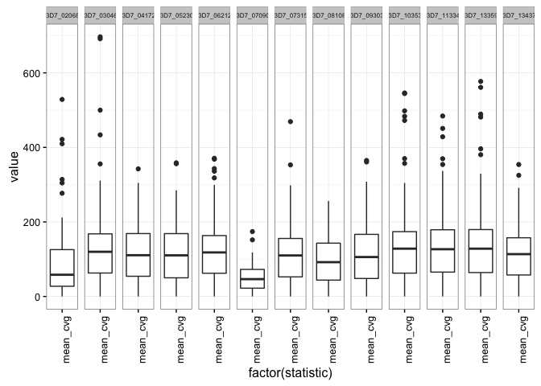

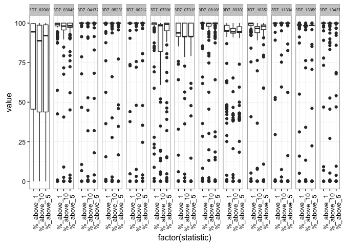

In general we are pretty well covered accross most resistance genes.

## 2.3 FastQC

We ran FastQC to check the base quality score distributions and GC content post alignment.

The summary results are located in data/qc/ and are available as zip files. Aside from the probelmatic samples identified above - generally the quality of the sequencing data was reasonble.

We provide links to the html files generated by FastQC for all samples here: PN0003_C PN0004_C PN0005_C PN0006_C PN0008_C PN0009_C PN0010_C PN0011_C PN0012_C PN0013_C PN0014_C PN0015_C PN0016_C PN0019_C PN0020_C PN0022_C PN0023_C PN0025_C PN0027_C PN0028_C PN0030_C PN0031_C PN0032_C PN0035_C PN0037_C PN0040_C PN0041_C PN0042_C PN0043_C PN0044_C PN0054_C PN0055_C PN0055_Cx PN0056_C PN0057_C PN0058_Cx PN0059_C PN0063_C PN0073_C PN0074_C PN0075_C PN0077_C PN0078_C PN0079_C PN0081_C PN0082_C PN0083_C PN0084_C PN0085_C PN0086_C PN0087_C PN0089_C PN0090_C PN0091_C PN0097_C PN0098_C PN0099_C PN0101_C PN0102_C PN0103_C PN0104_C PN0105_C PN0107_C PN0108_C PN0109_C PN0110_C PN0111_C PN0112_C PN0113_C PN0114_C PN0115_C PN0116_C PN0117_C PN0118_C PN0119_C PN0120_C PN0121_C PN0122_C PN0124_C PN0125_C PN0126_C PN0127_C PN0128_C PN0129_C PN0130_C PN0131_C PN0133_C PN0134_C PN0135_C PN0138_C PN0140_C PN0141_C PN0142_C PN0143_C PN0145_C PN0148_C PN0149_C PN0150_C PN0151_C PN0153_C PN0154_C PN0155_C PN0156_C PN0157_C PN0159_C PN0160_C PN0161_C PN0162_C PN0163_C PN0164_C PN0165_C PN0166_C PN0167_C PN0168_C PN0169_C PN0171_C PN0172_C PN0173_C PN0176_C PN0177_C PN0178_C PN0179_C PN0180_C PN0181_C PN0182_C PN0183_C PN0184_C PN0185_C PN0186_C PN0187_C PN0188_C PN0189_C PN0190_C PN0191_C PN0192_C PNG_DRS015A PNG_DRS034 PNG_XIA508 PNG_XPA028 PNG_XUA001 PNG_XUA011 PNG_XUA012 PNG_XUA020 PNG_XUA030 PNG_XUB001 PNG_XUC006 PNG_XUC009 PNG_XUC021 PNG_XUC022

## 2.4 Variant and sample filtering

After running the sequencing data through the updated variant calling pipeline, we initially filtered variants on the following characteristics

- remove indels
- keep only biallelic SNVs
- remove variants not on core chromosomal regions
- remove variants with VQSR LOD score less than or equal to 0.
- remove variants if there are three or more SNVs within a 30 base pair window

This left us with 71954 biallelic SNVs. To begin filtering we remove the problematic samples identified above according to the following criteria:

- remove a sample if less than 90% of their bases are not covered to at least 5 reads

This filter ensures that samples that consist of mostly human or Pvivax reads will be removed from downstream analysis, it also ensures that a sample should be genotyped with reasonable confidence.

```
## # of selected samples: 123
```

After applying this filter, we are left with 123 samples. Next we look at the quality annotations provided by the GATK Haplotype Caller output.

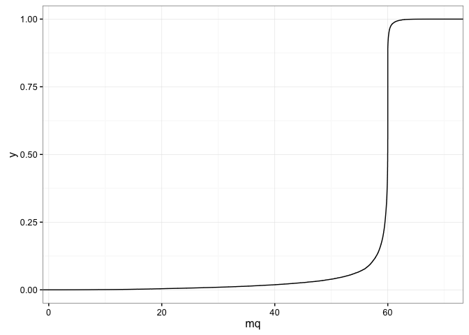

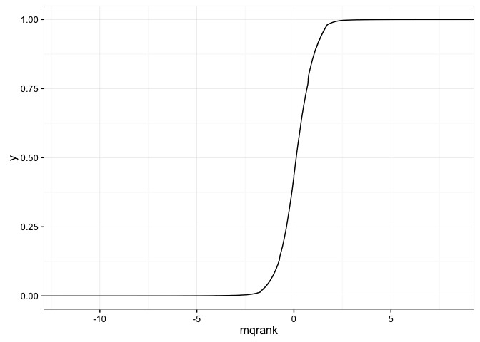

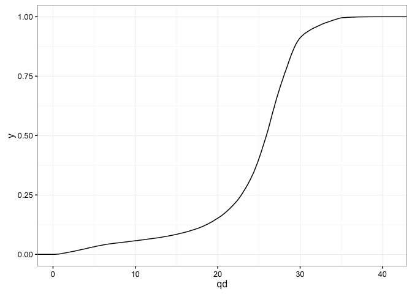

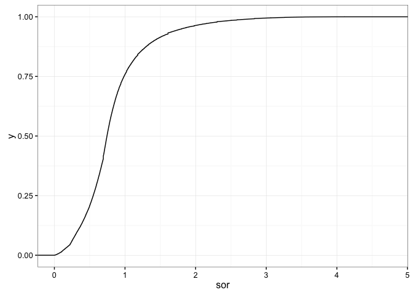

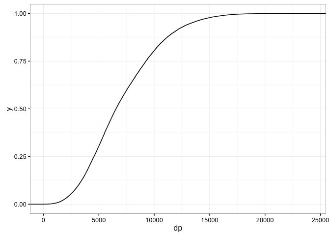

We apply some hard filters to all samples:

- QD score > 15
- SOR < 1
- MQRankSum > -2 (allowed to be missing for sites with heterozygous calls)
- MQ > 50
- DP between 3709 and 10704, these are the 15th and 85th percentiles of the coverage distribution, resepcitvely. This should prevent PCR amplification artefacts.

Next we look at the minor-allele frequency distribution estimated directly from the read-count data, we also look at the empirical coverage within samples distributions estimated at 5x, 10x, and 20x over all SNPs.

```
## # of selected variants: 33,423
```

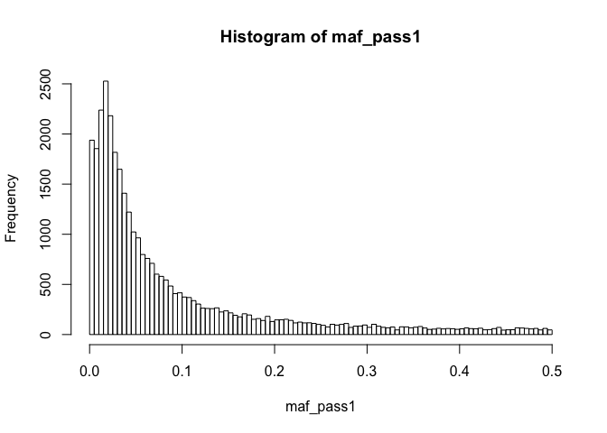

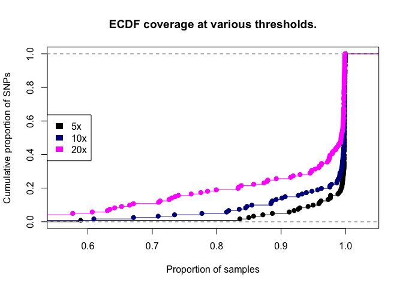

The MAF distribution looks similar to those found in other regions, where we find that many SNVs are rare in the populations of interest. We also find that the selected samples are fairly well covered accross all SNVs in the included set - meaning we can be relatively confident in their genotype calls.

# 3 Estimating MOI with $F_{ws}$

Next we estimate the $F_{ws}$ metric and plot the results.

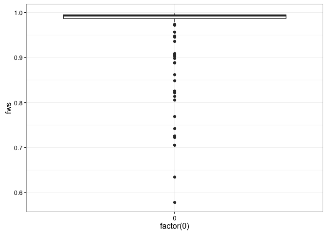

Using an $F_{ws}$ cut-off of 0.95, we obtain 22 multiclonal isoaltes, which aligns with previous estimates found in our old pipeline and using `moimix`.

# 4 Extracting data for IBD analysis

Next we extract data for IBD analysis using the MOI estimates obtained above. We also apply a MAF filter by selecting SNPs that are above 1% frequency. This reduces our callset to 29631 SNPs.

```
## # of selected variants: 29,631
```

```
## # of selected variants: 33,423
```

# 5 Extracting data for selection analysis

Finally, we output data for use in our selection piepline using the python package `scikit-allel`. We extract samples that have MOI = 1 and use the variant list we obtained before.

```
## [1] "Now creating HDF5 file for PNG"
```

# 6 Appendix